# Assignment 3

Metyu Melkonyan

2023-03-26

1. R language (R Core Team (2022)
2. Main article (Adams et al. (2019)
3. Rmarkdown (Allaire et al. (2021)
4. GSEA (Subramanian et al. (2005)
5. Bader Geneset (Merico (2010)
6. Hepatitis Article (Kamiza et al. (2022)
7. Cytoscape (Shannon et al. (2003)
8. GeneMania (Zuberi et al. (2013))
9. p53 (Aloni-Grinstein et al. (2018))
10. Sialic&cancer (Zhou, Yang, and Guan (2020))
11. Reactome (Gillespie et al. (2021))
12. Sialytion (Munkley and Scott (2019))
13. Drugbank (Wishart et al. (2006))

```r
if (!requireNamespace("GSA", quietly = TRUE)){
  install.packages("GSA")}
if (!requireNamespace("kable", quietly = TRUE)){
  install.packages("kable")}
```

## Introduction: Assignment 1 & Assignment 2

My dataset from GEO (Gene Expression Omnibus) is GSE131222 of Transcriptional control of sub-type switching ensures adaptation and growth of pancreatic cancer. My geneset aims to see the underlying ectopic expression of GLI2 expression in human pancreatic cancer cell lines specifically looking at YAPC cells. Moreover, 1 ug/ml of Dox treatment allowed for overexpression analysis of GLI2 by measuring via RNA-seq. on Illumina hiseq 2000. The authors used TopHat and Cufflinks for quality control and later used qRT-PCR along with SYBR Green assays to measure the intensity. By concluding oncogene genes and detecting induced-higher expression values compare to expression values 6 days before, GLI2 regulation of genes associated with basal-like sub-type switching was detected

Firstly, the data set I obtained from GEO was cleaned and filtered based on duplication. The normalized values of genes that are mostly miRNA genes are eliminated from the geneset. There have been instances that one row of expression has multiple genes associated. This was later found out on the second assignment where we believe this did not cause any problem, due to our limited analysis in the first assignment. Later I analyzed the dispersion among treatments of both triplicate controls that contain empty plasmid of GLI2 and experiments that contain inducible GLI2 plasmid! Since there might be a discrepancy among the gene annotation, which can cause a misunderstanding of our later analysis, I validated my HUGO gene symbols. Furthermore, by identifying HUGO symbols that are respective or similar to those that our clean data set contains. I was able to conclude that my dataset is clean, contains no duplicates as well as ready for the later analyses which are normalization, differential expression calculation, non-thresholded & thresholded gene enrichment analyses, fold expression based on the fitted model of GLI2 expression set, and finally for the enrichment mapping with post analysis.

Secondly, by preliminary analyzing the differential expression of our dataset via heat map I have concluded that there is a strong difference between the treatment of GLI2 and the control cells in terms of their summarized gene expression by the model. Later, by visualizing the p-value distribution I concluded most of the oncogenes referred on the main article are clustered at the specified p-value interval. Later sample clustering summarized the gene expression difference between the treatment and the control genes. Stringently analyzing Lastly, the non-thresholded gene enrichment map both allowed me to observe genes that are passing our permissive FDR values as well as defined the pathways that are found to be associated with oncogenes. These pathways are then altered visualized and used to conclude that by doing all the analysis on assignment 2, I was able to differentiate the genes that are related to sub-type switching (EMT) and those that are not (non-EMT). Finally, I have separated two data from each other and obtained a ranked gene list based additionally. These analyses taught me how to select a dataset, clean a dataset, normalize it, analyze to what extent the genes are expressed differentially from one another, and see how the genes are interacting genes in a given pathway or a given gene set. Also, finally, validate the author’s conclusion or come up with my conclusion and promote further research in the area. In this final assignment of mine, I will be concluding my analyses with enrichment mapping by using Cytoscape and its apps as well as conservatively geneset.

## Part 1: Non-thresholded Gene set Enrichment Analysis

I have used GSEA (4.3.2) (4) non-thresholded gene set enrichment method. I have used the Bader Lab geneset of Human_GOBP_AllPathways_no_GO_iea_March_01_2021_symbol.gmt including no HUGO symbols and IEA symbols published on March 1, 2021. It was released in 2023 by Human MiSigDB. I used no collapse to remap gene symbols to avoid confusion. 200 max gene size and 15 min gene size to have more stringent values. I used 1000 permutations that allowed for a shorter running time. Therefore, GSEA resulted in more stringent non-EMT values that are shown to be enriched. There are pathways of genes that are known to be involved in apoptosis. The top gene set at the positive geneset is TRANSCRIPTIONAL REGULATION BY SMALL RNAS%REACTOME%R-HSA-5578749.3 with 0.784 FDR-value and 0.001 Nominal p-values and 0.98 ES score. The top gene set for negative is PHOSPHOLIPASES%HUMANCYC%LIPASYN-PWY with 0 FDR and 0 p-value and-0.65 ES. This makes sense because, with my previous results that my log CPM is always negative, there are no positive log CPM values. This was my previous hypothesis that almost every gene treated showed higher expression with the treatments the authors did to induce oncogenic roles.

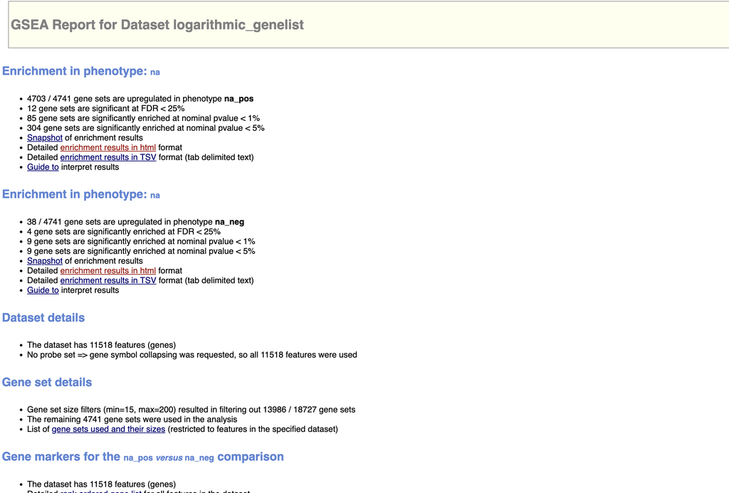

Figure 1: GSEA Enrichment Results

GSE results indicate there are 4703 upregualted gene sets and 38 down regulated gene sets.

#### Upregulated

- 12 gene sets < 25% FDR
- 85 gene sets < 1% p-value
- 304 gene sets < 5% nominal p-value

#### Downregulated

- 4 gene sets < 25 % FDR
- 9 gene sets < 1% p-value
- 9 gene sets < 5% p-value

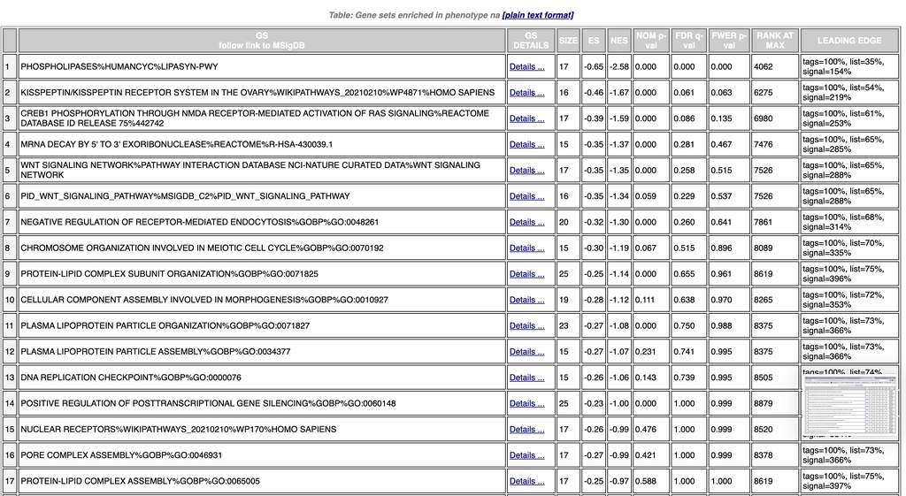

Figure 2: Negative Enrichment Results. It shows PHOSPHOLIPASES%HUMANCYC%LIPASYN-PWY is the top gene set

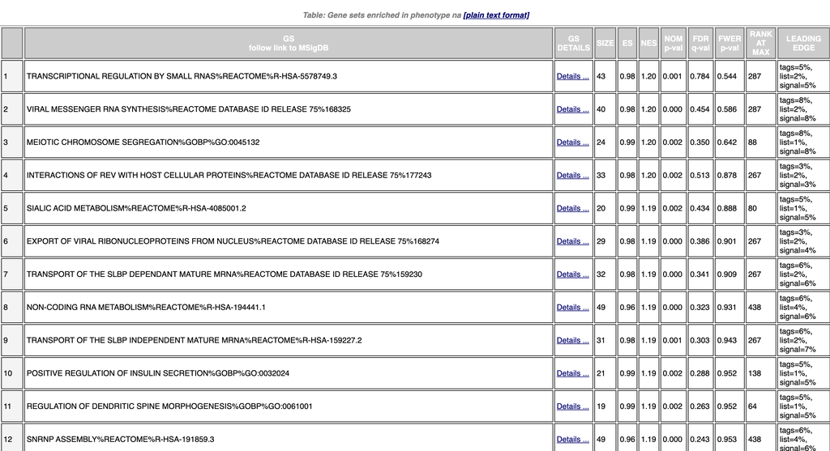

Figure 3: Positive Enrichment Results. It shows that the TRANSCRIPTIONAL REGULATION BY SMALL RNAS%REACTOME%R-HSA-5578749.3 is the top gene set

## Part 2: Visualize your Gene set Enrichment Analysis in Cytoscape

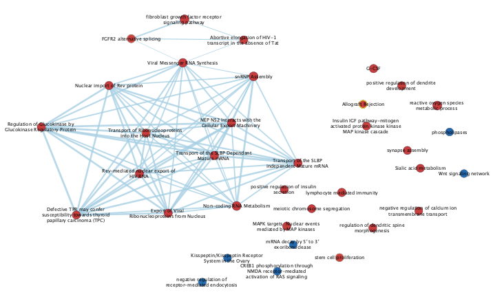

Figure 4: Cytoscape Pathway Enrichment Visualization. Both apoptotic and viral geneset are separated from each other. Mesenchymal apoptotic geene sets are apperent

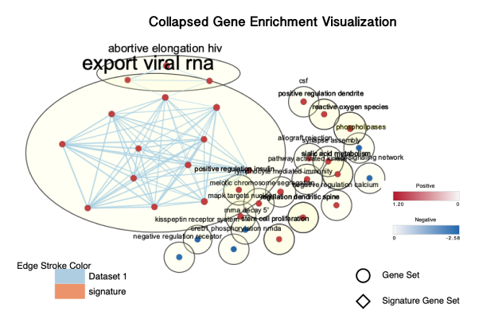

Figure 5:Publication-ready-figure of Gene Enrichment visualization (7)

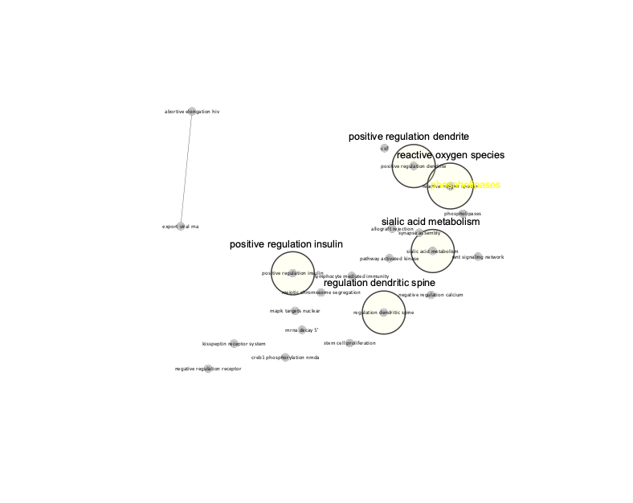

Figure 6:Collapsed themed enrhicment map figure of Gene Enrichment visualization

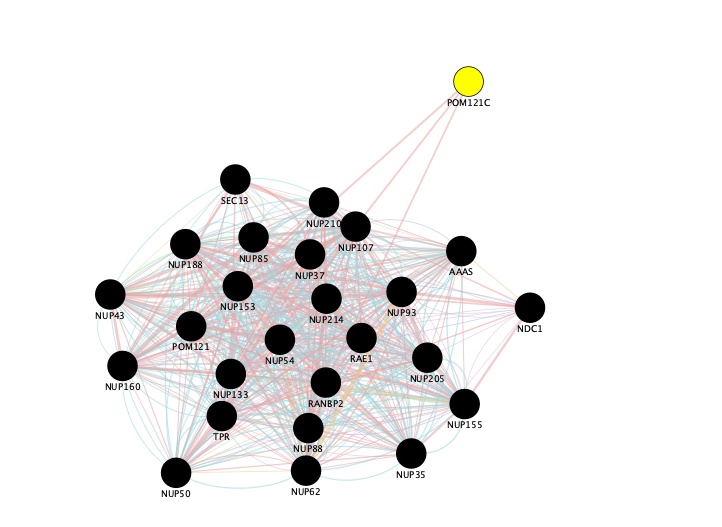

```r
 Genemania <- read.csv(file=file.path(getwd(),"data","table_genemania.csv"))
knitr::kable(Genemania, type="html")
```

| EnrichmentMap..Expression | gene.name | log.score | name | node.type | query.term | score | shared.name |
| --- | --- | --- | --- | --- | --- | --- | --- |
| 0.0000 | NUP50 | -0.4593206 | H__sapiens__1_-774733 | query | NUP50 | 0.6317127 | H__sapiens__1_-774733 |
| 0.0000 | NUP205 | -0.3864459 | H__sapiens__1_-782635 | query | NUP205 | 0.6794675 | H__sapiens__1_-782635 |
| 0.0000 | RANBP2 | -0.6944706 | H__sapiens__1_-782386 | query | RANBP2 | 0.4993387 | H__sapiens__1_-782386 |
| 0.0000 | TPR | -0.4513919 | H__sapiens__1_-773361 | query | TPR | 0.6367412 | H__sapiens__1_-773361 |
| 0.0000 | POM121 | -0.3202072 | H__sapiens__1_-789815 | query | POM121 | 0.7259986 | H__sapiens__1_-789815 |
| 0.0000 | NUP88 | -0.4133439 | H__sapiens__1_-776294 | query | NUP88 | 0.6614348 | H__sapiens__1_-776294 |
| 0.0000 | NUP188 | -0.4694928 | H__sapiens__1_-774764 | query | NUP188 | 0.6253193 | H__sapiens__1_-774764 |
| 0.0000 | NUP133 | -0.4971920 | H__sapiens__1_-773810 | query | NUP133 | 0.6082362 | H__sapiens__1_-773810 |
| 0.0000 | RAE1 | -0.5025908 | H__sapiens__1_-775191 | query | RAE1 | 0.6049613 | H__sapiens__1_-775191 |
| 35.8284 | NUP160 | -0.4609759 | H__sapiens__1_-773223 | query | NUP160 | 0.6306679 | H__sapiens__1_-773223 |
| 0.0000 | NUP155 | -0.4669676 | H__sapiens__1_-776946 | query | NUP155 | 0.6269004 | H__sapiens__1_-776946 |
| 0.0000 | NUP54 | -0.4274837 | H__sapiens__1_-780479 | query | NUP54 | 0.6521480 | H__sapiens__1_-780479 |
| 0.0000 | NUP153 | -0.5116202 | H__sapiens__1_-778335 | query | NUP153 | 0.5995235 | H__sapiens__1_-778335 |
| 0.0000 | NUP214 | -0.5148612 | H__sapiens__1_-778618 | query | NUP214 | 0.5975835 | H__sapiens__1_-778618 |
| 0.0000 | SEC13 | -0.5645876 | H__sapiens__1_-782804 | query | SEC13 | 0.5685946 | H__sapiens__1_-782804 |
| 0.0000 | NDC1 | -0.1134623 | H__sapiens__1_-773535 | query | NDC1 | 0.8927378 | H__sapiens__1_-773535 |
| 0.0000 | NUP37 | -0.4418337 | H__sapiens__1_-774031 | query | NUP37 | 0.6428565 | H__sapiens__1_-774031 |
| 0.0000 | AAAS | -0.3917891 | H__sapiens__1_-774750 | query | AAAS | 0.6758466 | H__sapiens__1_-774750 |
| 0.0000 | NUP85 | -0.4620475 | H__sapiens__1_-778398 | query | NUP85 | 0.6299924 | H__sapiens__1_-778398 |
| 0.0000 | NUP43 | -0.4713705 | H__sapiens__1_-777773 | query | NUP43 | 0.6241463 | H__sapiens__1_-777773 |
| 0.0000 | NUP107 | -0.5350951 | H__sapiens__1_-776652 | query | NUP107 | 0.5856136 | H__sapiens__1_-776652 |
| 0.0000 | NUP93 | -0.4014051 | H__sapiens__1_-775466 | query | NUP93 | 0.6693788 | H__sapiens__1_-775466 |
| 0.0000 | NUP210 | -0.3976326 | H__sapiens__1_-779292 | query | NUP210 | 0.6719089 | H__sapiens__1_-779292 |
| 0.0000 | NUP35 | -0.3966731 | H__sapiens__1_-783644 | query | NUP35 | 0.6725539 | H__sapiens__1_-783644 |
| 0.0000 | NUP62 | -0.4904854 | H__sapiens__1_-795021 | query | NUP62 | 0.6123291 | H__sapiens__1_-795021 |
| 0.0000 | POM121C | -0.0841121 | H__sapiens__1_-826631 | query | POM121C | 0.9193282 | H__sapiens__1_-826631 |

## Part 3: Post Analysis Summary

```r
library(GSA)
gmt_file <- file.path(getwd(),"data",
  "Human_GOBP_AllPathways_no_GO_iea_March_01_2021_symbol.gmt")
capture.output(genesets<-
GSA.read.gmt(gmt_file),file="GSA_file.txt")
names(genesets$genesets) <- genesets$geneset.names
knitr::kable(head(genesets$geneset.names), type="html")
```

| x |
| --- |
| PROTEIN CITRULLINATION%HUMANCYC%PWY-4921 |
| METHYLGLYOXAL DEGRADATION III%HUMANCYC%PWY-5453 |
| STEARATE BIOSYNTHESIS I (ANIMALS)%HUMANCYC%PWY-5972 |
| TRYPTOPHAN DEGRADATION X (MAMMALIAN, VIA TRYPTAMINE)%HUMANCYC%PWY-6307 |
| CERAMIDE BIOSYNTHESIS%HUMANCYC%PWY3DJ-12 |
| L-SERINE DEGRADATION%HUMANCYC%SERDEG-PWY |

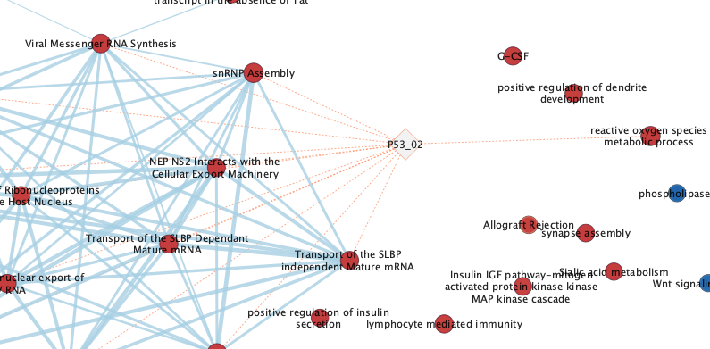

Figure 8: p53 Signature geneset

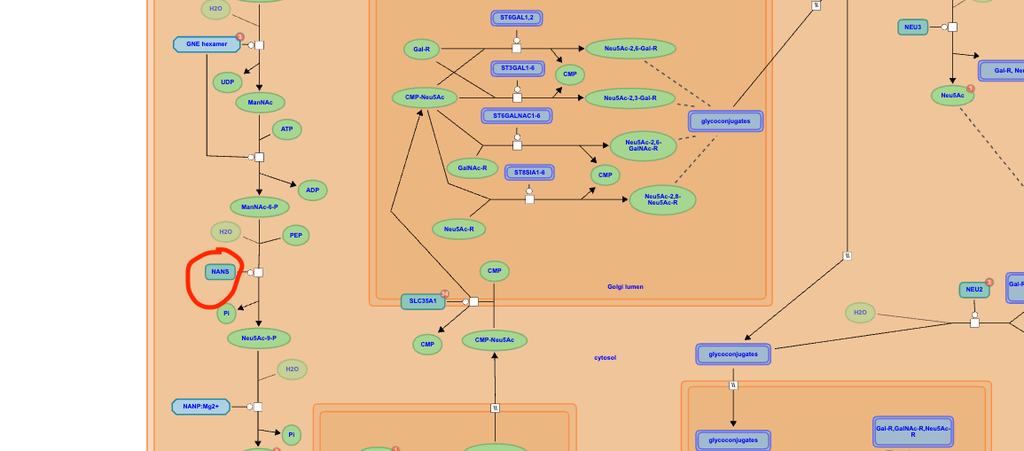

Figure 9: NANS (enricled red) Sialic Acid pathway of Homo sapiens(11)

The sialic acid pathway is one of the pathways that is known to be affecting tumour proliferation, cell growth, cell detachment and as a result metastasis. It is known to be highly expressed by the cancer cell. Moreover, cancer-triggered apoptosis is one of the results of sialic acid. Neu5Ac 9-phosphate synthase (NANS)( encircled red) is an enzyme in sialic acid metabolism.NANS’ role in sialic acid pathways on the figure. Also, glycolipid-bound sialic acids are highly found in cancer cells. Finally, by having high expression levels and visualized on the pathway analysis NANS has the potential to be an oncogene. The role of sialic acid differs as there is an interaction between cancer genes and the viral genes, I do hypothesize that cancer causing viruses are an important factor in high sialic acid levels in pancreas cancer.

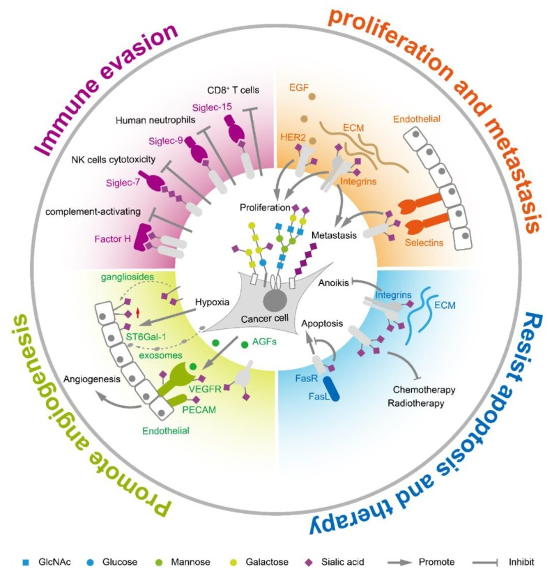

Figure 10: Oncogenic role of Sialic acid Metabolism (10)

## Part 4: Interpretation and detailed view of results

1.Do the enrichment results support conclusions or mechanism discussed in the original paper? How do these results differ from the results you got from Assignment 2 thresholded methods ?

Yes, the enrichment results support the conclusion. It not only supports the conclusion of EMT genes that are known to be unregulated and found on the positive side of the gene enrichment analysis but also a finding of viral effect. This viral effect on different types of cancer has been discussed in different literature. However, the cancer oncogene p53 has a relationship with oncogenic viral cancer-inducing genes. Further research is required to illustrate both pancreas cancer and much other cancer. The results that we obtained from the thresholded analysis are partly different from what we obtained from the non-thresholded analysis. I am confident that this is due to the gene-set difference as well as experimental errors in data analysis. However, we were lucky to get partial positive results and conclude similarly to the main paper’s conclusion.

#### Conclusion

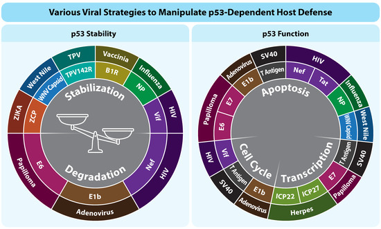

## Reference

Adams, Christina R, Htet Htwe Htwe, Timothy Marsh, Aprilgate L Wang, Megan L Montoya, Lakshmipriya Subbaraj, Aaron D Tward, Nabeel Bardeesy, and Rushika M Perera. 2019. “Transcriptional Control of Subtype Switching Ensures Adaptation and Growth of Pancreatic Cancer.” *Elife* 8: e45313.

Allaire, JJ, Yihui Xie, Jonathan McPherson, Javier Luraschi, Kevin Ushey, Aron Atkins, Hadley Wickham, Joe Cheng, Winston Chang, and Richard Iannone. 2021. *rmarkdown: Dynamic Documents for R*. https://github.com/rstudio/rmarkdown.

Aloni-Grinstein, Ronit, Meital Charni-Natan, Hilla Solomon, and Varda Rotter. 2018. “P53 and the Viral Connection: Back into the Future ‡.” *Cancers* 10 (6). https://doi.org/10.3390/cancers10060178.

Gillespie, Marc, Bijay Jassal, Ralf Stephan, Marija Milacic, Karen Rothfels, Andrea Senff-Ribeiro, Johannes Griss, et al. 2021. “The reactome pathway knowledgebase 2022.” *Nucleic Acids Research* 50 (D1): D687–92. https://doi.org/10.1093/nar/gkab1028.

Kamiza, Abram Bunya, Segun Fatumo, Mwiza Gideon Singini, Chih-Ching Yeh, and Tinashe Chikowore. 2022. “Hepatitis B Infection Is Causally Associated with Extrahepatic Cancers: A Mendelian Randomization Study.” *EBioMedicine* 79 (April): 104003.

Merico, Ruth AND Stueker, Daniele AND Isserlin. 2010. “Enrichment Map: A Network-Based Method for Gene-Set Enrichment Visualization and Interpretation.” *PLOS ONE* 5 (11): 1–12. https://doi.org/10.1371/journal.pone.0013984.

Munkley, Jennifer, and Emma Scott. 2019. “Targeting Aberrant Sialylation to Treat Cancer.” *Medicines (Basel)* 6 (4).

R Core Team. 2022. *R: A Language and Environment for Statistical Computing*. Vienna, Austria: R Foundation for Statistical Computing. https://www.R-project.org/.

Shannon, Paul, Andrew Markiel, Owen Ozier, Nitin S Baliga, Jonathan T Wang, Daniel Ramage, Nada Amin, Benno Schwikowski, and Trey Ideker. 2003. “Cytoscape: A Software Environment for Integrated Models of Biomolecular Interaction Networks.” *Genome Res* 13 (11): 2498–2504.

Subramanian, Aravind, Pablo Tamayo, Vamsi K. Mootha, Sayan Mukherjee, Benjamin L. Ebert, Michael A. Gillette, Amanda Paulovich, et al. 2005. “Gene Set Enrichment Analysis: A Knowledge-Based Approach for Interpreting Genome-Wide Expression Profiles.” *Proceedings of the National Academy of Sciences* 102 (43): 15545–50. https://doi.org/10.1073/pnas.0506580102.

Wishart, David S, Craig Knox, An Chi Guo, Savita Shrivastava, Murtaza Hassanali, Paul Stothard, Zhan Chang, and Jennifer Woolsey. 2006. “DrugBank: A Comprehensive Resource for in Silico Drug Discovery and Exploration.” *Nucleic Acids Res* 34 (Database issue): D668–72.

Zhou, Xiaoman, Ganglong Yang, and Feng Guan. 2020. “Biological Functions and Analytical Strategies of Sialic Acids in Tumor.” *Cells* 9 (2).

Zuberi, Khalid, Max Franz, Harold Rodriguez, Jason Montojo, Christian Tannus Lopes, Gary D Bader, and Quaid Morris. 2013. “GeneMANIA Prediction Server 2013 Update.” *Nucleic Acids Res* 41 (Web Server issue): W115–22.